# FA#1

2024-02-13

1.Choose one of the columns of the dataset and make at least two plots showing its distribution (choose from ECDF, quantile, histogram, density estimate). What does the plot tell you about the distribution of the values in that column?

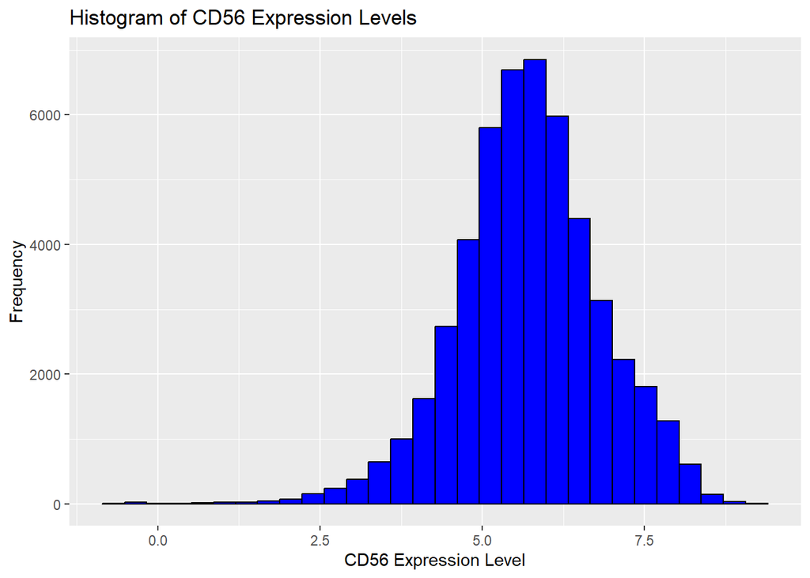

```r
library(ggplot2)
library(readr)
file_path <- "D:/desktop/cytof_one_experiment.csv"
data <- read_csv(file_path)
ggplot(data, aes(x = CD56)) +
  geom_histogram(bins = 30, fill = "blue", color = "black") +
  ggtitle("Histogram of CD56 Expression Levels") +
  xlab("CD56 Expression Level") +
  ylab("Frequency")
```

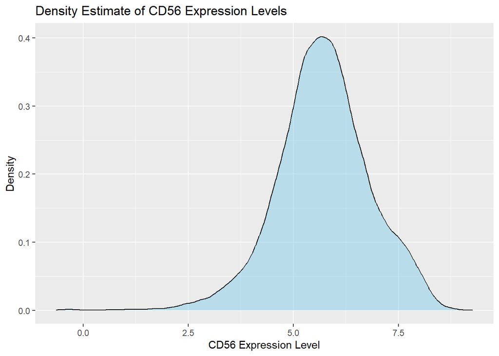

```r
ggplot(data, aes(x = CD56)) +
  geom_density(fill = "skyblue", alpha = 0.5) +
  ggtitle("Density Estimate of CD56 Expression Levels") +
  xlab("CD56 Expression Level") +
  ylab("Density")
```

2.Choose any two of the columns of the dataset and make a Q-Q plot comparing the distributions. What does the Q-Q plot tell you about similarities or differences between the distributions of the values in the two columns?

```r
library(readr)

file_path <- "D:/desktop/cytof_one_experiment.csv"
data <- read_csv(file_path)
```

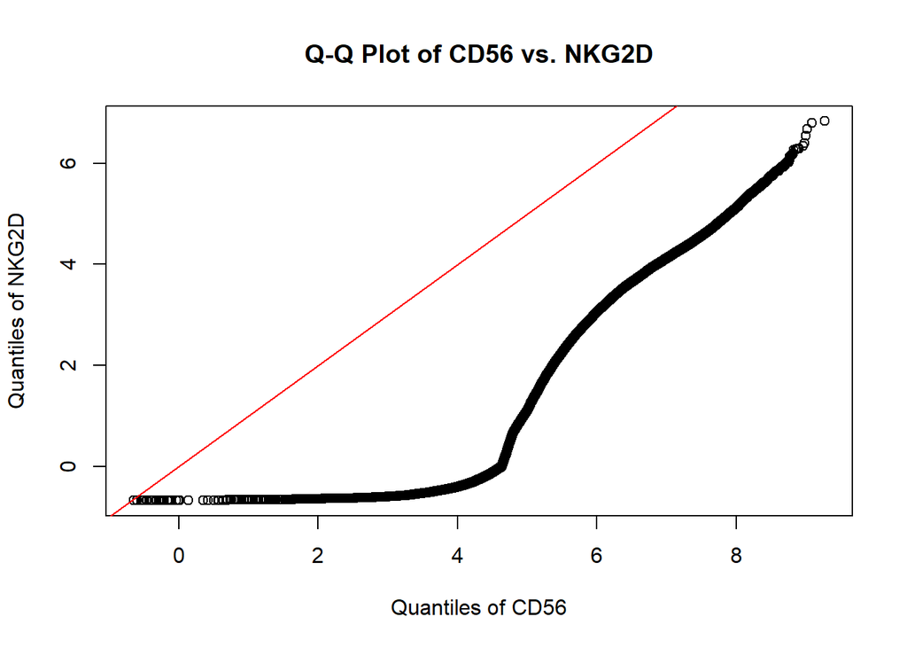

```r
x <- data$CD56
y <- data$NKG2D

qqplot(x, y, main = "Q-Q Plot of CD56 vs. NKG2D", xlab = "Quantiles of CD56", ylab = "Quantiles of NKG2D")
abline(0, 1, col = "red")
```

Interpretation of the Q-Q Plot A Q-Q plot compares the quantiles of two distributions by plotting their quantiles against each other. If the two distributions are similar, the points in the Q-Q plot will lie approximately along a straight line.

If the points deviate from the straight line significantly, it indicates that the distributions differ in some way. This deviation could manifest as points curving away from the line at either end, indicating differences in the tails of the distributions, or a slope change, indicating differences in dispersion or central tendency. Points lying above the line suggest that the distribution on the y-axis has higher quantiles than the distribution on the x-axis at those points, and vice versa for points lying below the line.